# Assignment 2

Due Time: February 17th, 5pm

Name: **Muyang Huang**

## 1. n-gram

Given the training data

```
<s> John read a book by Jane </s>
<s> John read another book </s>
<s> I read a different book </s>
```

### (a) Calculate bigrams using **maximum likelihood estimates (MLE)** and fill out the table.

```python
from collections import Counter, defaultdict
import numpy as np

def compute_bigram_mle(sentences):
    bigram_counts = Counter()
    unigram_counts = Counter()

    # Tokenize and count n-grams
    for sentence in sentences:
        tokens = sentence.split()
        unigrams = tokens
        bigrams = [(tokens[i], tokens[i+1]) for i in range(len(tokens)-1)]

        unigram_counts.update(unigrams)
        bigram_counts.update(bigrams)

    # Compute MLE probabilities
    bigram_probabilities = {}
    for (w1, w2), count in bigram_counts.items():
        bigram_probabilities[(w1, w2)] = count / unigram_counts[w1]

    return bigram_probabilities

# Training data
sentences = [
    "<s> John read a book by Jane </s>",
    "<s> John read another book </s>",
    "<s> I read a different book </s>"
]

bigram_mle = compute_bigram_mle(sentences)

# Print results
bigrams_to_check = [('<s>', 'John'), ('John', 'read'), ('read', 'a'), ('a', 'book'), ('book', 'by'), ('by', 'Jane'),
                    ('Jane', '</s>'), ('read', 'another'), ('another', 'book'), ('book', '</s>'), ('<s>', 'I'),
                    ('I', 'read'), ('a', 'different'), ('different', 'book')]

for bigram in bigrams_to_check:
    print(f"P({bigram[1]}|{bigram[0]}) = {bigram_mle.get(bigram, 0):.3f}")
```

```
P(John|<s>) = 0.667
P(read|John) = 1.000
P(a|read) = 0.667
P(book|a) = 0.500
P(by|book) = 0.333
P(Jane|by) = 1.000
P(</s>|Jane) = 1.000
P(another|read) = 0.333
P(book|another) = 1.000
P(</s>|book) = 0.667
P(I|<s>) = 0.333
P(read|I) = 1.000
P(different|a) = 0.500
P(book|different) = 1.000
```

| **Bigram** | **Probability** | **Bigram** | **Probability** |
| --- | --- | --- | --- |
| P(John\|< s>) | 0.667 | P(another\|read) | 0.333 |
| P(read\|John) | 1.000 | P(book\|another) | 1.000 |
| P(a\|read) | 0.667 | P(</s>\|book) | 0.667 |
| P(book\|a) | 0.500 | P(I\|< s>) | 0.333 |
| P(by\|book) | 0.333 | P(read\|I) | 1.000 |
| P(Jane\|by) | 1.000 | P(different\|a) | 0.500 |
| P(</s>\|Jane) | 1.000 | P(book\|different) | 1.000 |

### (b) Calculate the sentence probability of *< s> John read a different book </s>* using only MLE bigram.

```python
def compute_sentence_probability(sentence, bigram_mle):
    tokens = sentence.split()
    bigrams = [(tokens[i], tokens[i+1]) for i in range(len(tokens)-1)]

    prob = 1.0
    for bigram in bigrams:
        prob *= bigram_mle.get(bigram, 0)

    return prob

# Compute sentence probability
sentence = "<s> John read a different book </s>"
sentence_prob = compute_sentence_probability(sentence, bigram_mle)
print(f"The sentence probability of '{sentence}' is {sentence_prob:.3f}.")
```

```
The sentence probability of '<s> John read a different book </s>' is 0.148.
```

### (c) Calculate the sentence probability of *< s> Jane read a book </s>* using only MLE bigram.

```python
sentence = "<s> Jane read a book </s>"
sentence_prob = compute_sentence_probability(sentence, bigram_mle)
print(f"The sentence probability of '{sentence}' is {sentence_prob:.3f}.")
```

```
The sentence probability of '<s> Jane read a book </s>' is 0.000.
```

## 2. Evaluation metrics on binary classification

Given the following output,

| **Actual Label** | **Predicted Label** |
| --- | --- |
| 0 | 0 |
| 1 | 1 |
| 0 | 1 |
| 0 | 1 |
| 1 | 1 |
| 0 | 0 |
| 1 | 1 |
| 0 | 1 |
| 1 | 0 |
| 0 | 1 |

### (a) Draw the confusion matrix.

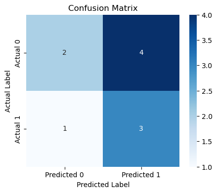

```
Confusion Matrix:
[[2 4]
 [1 3]]
```

```python
from sklearn.metrics import confusion_matrix
import seaborn as sns
import matplotlib.pyplot as plt

# Given actual and predicted labels
actual_labels = [0, 1, 0, 0, 1, 0, 1, 0, 1, 0]
predicted_labels = [0, 1, 1, 1, 1, 0, 1, 1, 0, 1]

# Compute confusion matrix
cm = confusion_matrix(actual_labels, predicted_labels)

# Plot confusion matrix
plt.figure(figsize=(5, 4))
sns.heatmap(cm, annot=True, fmt='d', cmap='Blues', xticklabels=['Predicted 0', 'Predicted 1'], yticklabels=['Actual 0', 'Actual 1'])
plt.xlabel("Predicted Label")
plt.ylabel("Actual Label")
plt.title("Confusion Matrix")
plt.show()

# Print confusion matrix values
print("Confusion Matrix:")
print(cm)
```

### (b) Calculate the Accuracy, Precision, Recall, and F1 score.

```python
from sklearn.metrics import accuracy_score, precision_score, recall_score, f1_score

# Given confusion matrix values
TP = 3 # True Positives (Actual 1, Predicted 1)
TN = 2 # True Negatives (Actual 0, Predicted 0)
FP = 4 # False Positives (Actual 0, Predicted 1)
FN = 1 # False Negatives (Actual 1, Predicted 0)

# Compute evaluation metrics
accuracy = (TP + TN) / (TP + TN + FP + FN)
precision = TP / (TP + FP)
recall = TP / (TP + FN)
f1 = 2 * (precision * recall) / (precision + recall)

# Print results
print(f"The Accuracy, precision, recall, and F1 Score are {accuracy:.3f}, {precision:.3f}, {recall:.3f}, and {f1:.3f}, respectively.")
```

```
The Accuracy, precision, recall, and F1 Score are 0.500, 0.429, 0.750, and 0.545, respectively.
```

### (c) Why might using accuracy as the only metric is not ideal?

**Answer**: Accuracy alone can be misleading, especially in cases of class imbalance, where a model can achieve high accuracy by predicting the majority class while failing on the minority class. Also, it does not distinguish between false positives and false negatives, which can have different real-world consequences such as medical diagnoses. Metrics like precision, recall, and F1 score provide a more balanced evaluation by considering both types of errors, which makes them more reliable for assessing model performance in imbalanced datasets.

## 3. Evaluation metrics on multiclass classification

Given the following confusion matrix of a multi-label classifier

|  | **A** | **B** | **C** | **D** | **E** | **F** |
| --- | --- | --- | --- | --- | --- | --- |
| **A** | 95 | 1 | 13 | 0 | 1 | 0 |
| **B** | 0 | 1 | 0 | 0 | 0 | 0 |
| **C** | 10 | 90 | 0 | 1 | 0 | 0 |
| **D** | 0 | 0 | 0 | 34 | 3 | 7 |
| **E** | 0 | 1 | 2 | 13 | 26 | 5 |
| **F** | 0 | 0 | 2 | 14 | 5 | 10 |

### (a) Calculate the precision, recall, and F1 for classes A-F

```python
# Given confusion matrix
confusion_matrix = np.array([
    [95, 1, 13, 0, 1, 0],
    [0, 1, 0, 0, 0, 0],
    [10, 90, 0, 1, 0, 0],
    [0, 0, 0, 34, 3, 7],
    [0, 1, 2, 13, 26, 5],
    [0, 0, 2, 14, 5, 10]
])

# Extract true labels and predicted labels
true_labels = []
predicted_labels = []

for true_class in range(confusion_matrix.shape[0]):
    for predicted_class in range(confusion_matrix.shape[1]):
        true_labels.extend([true_class] * confusion_matrix[true_class, predicted_class])
        predicted_labels.extend([predicted_class] * confusion_matrix[true_class, predicted_class])

# Compute precision, recall, and F1-score
precision = precision_score(true_labels, predicted_labels, average=None)
recall = recall_score(true_labels, predicted_labels, average=None)
f1 = f1_score(true_labels, predicted_labels, average=None)

# Print results for each class
classes = ['A', 'B', 'C', 'D', 'E', 'F']
for i, cls in enumerate(classes):
    print(f"For class {cls}, the precision, recall, and F1 are {precision[i]:.4f}, {recall[i]:.4f}, and {f1[i]:.4f}, respectively.")
```

```
For class A, the precision, recall, and F1 are 0.9048, 0.8636, and 0.8837, respectively.
For class B, the precision, recall, and F1 are 0.0108, 1.0000, and 0.0213, respectively.
For class C, the precision, recall, and F1 are 0.0000, 0.0000, and 0.0000, respectively.
For class D, the precision, recall, and F1 are 0.5484, 0.7727, and 0.6415, respectively.
For class E, the precision, recall, and F1 are 0.7429, 0.5532, and 0.6341, respectively.
For class F, the precision, recall, and F1 are 0.4545, 0.3226, and 0.3774, respectively.
```

### (b) Calculate the micro-average precision, recall, and F1

```python
# Compute micro-average precision, recall, and F1-score
micro_precision = precision_score(true_labels, predicted_labels, average='micro')
micro_recall = recall_score(true_labels, predicted_labels, average='micro')
micro_f1 = f1_score(true_labels, predicted_labels, average='micro')

# for i, cls in enumerate(classes):
#     print(f"For class {cls}, the micro-average precision, recall, and F1 are {micro_precision[i]:.4f}, {micro_recall[i]:.4f}, and {micro_f1[i]:.4f}, respectively.")

# Print micro-average metrics
print(f"The micro-average precision, recall, and F1 are {micro_precision:.3f}, {micro_recall:.3f}, and {micro_f1:.3f}, respectively.")
```

```
The micro-average precision, recall, and F1 are 0.497, 0.497, and 0.497, respectively.
```

### (c) Calculate the macro-average precision, recall, and F1

```python
# Compute macro-average precision, recall, and F1-score
macro_precision = precision_score(true_labels, predicted_labels, average='macro')
macro_recall = recall_score(true_labels, predicted_labels, average='macro')
macro_f1 = f1_score(true_labels, predicted_labels, average='macro')

# Print macro-average metrics
print(f"The macro-average precision, recall, and F1 are {macro_precision:.3f}, {macro_recall:.3f}, and {macro_f1:.3f}, respectively.")
```

```
The macro-average precision, recall, and F1 are 0.444, 0.585, and 0.426, respectively.
```

## 4. Text classfication

### (a) Use *BernoulliNB* to build a naïve Bayes classifier.

| **BernoulliNB** | **true positive** | **false positive** | **false negative** | **precision** | **recall** | **F1-score** |
| --- | --- | --- | --- | --- | --- | --- |
| **positive** | 30,523 | 3,229 | 4,917 | 0.904 | 0.861 | 0.882 |
| **negative** | 10,268 | 4,917 | 3,229 | 0.676 | 0.761 | 0.716 |

### (b) Repeat the process in Task (a), but use the SVM (*SGDClassifier*) model.

| **SGDClassifier** | **true positive** | **false positive** | **false negative** | **precision** | **recall** | **F1-score** |
| --- | --- | --- | --- | --- | --- | --- |
| **positive** | 33,542 | 4,154 | 1,898 | 0.890 | 0.946 | 0.917 |
| **negative** | 9,343 | 1,898 | 4,154 | 0.831 | 0.692 | 0.755 |

### (c) Upload the source codes.

```python
## Source codes for 4(a):

print("BernoulliNB (naïve Bayes classifier):")

from sklearn.feature_extraction.text import CountVectorizer
# from sklearn.model_selection import train_test_split, cross_val_score
from sklearn.naive_bayes import BernoulliNB
from sklearn.metrics import confusion_matrix, precision_recall_fscore_support
import csv

# Load dataset
train_lines = []
train_labels = []
with open("drug_review_train.csv", "r", encoding="utf8") as fp:
    fp = csv.reader(fp)
    next(fp) # Skip header
    for line in fp:
        if line[2] == "1" or line[2] == "-1":
            train_lines.append(line[1])
            train_labels.append(int(line[2]))

test_lines = []
test_labels = []
with open("drug_review_test.csv", "r", encoding="utf8") as fp:
    fp = csv.reader(fp)
    next(fp) # Skip header
    for line in fp:
        if line[2] == "1" or line[2] == "-1":
            test_lines.append(line[1])
            test_labels.append(int(line[2]))

# Convert text to binary feature representation
count_vectorizer = CountVectorizer(binary=True)
X_train = count_vectorizer.fit_transform(train_lines)
X_test = count_vectorizer.transform(test_lines)
y_train = np.array(train_labels)
y_test = np.array(test_labels)

# Split dataset
# X_train, X_test, y_train, y_test = train_test_split(X, y, test_size=0.33, random_state=42)

# Train Bernoulli Naïve Bayes classifier
classifier = BernoulliNB()
classifier.fit(X_train, y_train)

# Predict on test set
y_pred = classifier.predict(X_test)

# Calculate confusion matrix
# cm = confusion_matrix(y_test, y_pred) # Compute confusion matrix
# tn, fp, fn, tp = cm.ravel() # Unpack values to extract TN, FP, FN, TP
tn, fp, fn, tp = confusion_matrix(y_test, y_pred).ravel()
print(f"The true positives, true negatives, false positives, and false negatives are {round(tp, 3)}, {round(tn, 3)}, {round(fp, 3)}, and {round(fn, 3)}, respectively.")

# Evaluate performance
pre, recall, f1, support = precision_recall_fscore_support(y_test, y_pred, average='binary')
print(f"The precision, recall, and F1-score are {round(pre, 3)}, {round(recall, 3)}, and {round(f1, 3)}, respectively.\n")

# a = 10268 / (10268 + 4917)
# b = 10268 / (10268 + 3229)
# print(round(a, 3))
# print(round(b, 3))
# print(round(2 * a * b / (a + b), 3))


## Source codes for 4(b):

print("SVM (SGDClassifier) model:")

from sklearn.linear_model import SGDClassifier

# Train SVM (SGDClassifier) model
classifier = SGDClassifier(loss="hinge", random_state=88)
classifier.fit(X_train, y_train)

# Predict on test set
y_pred = classifier.predict(X_test)

# Calculate confusion matrix
tn, fp, fn, tp = confusion_matrix(y_test, y_pred).ravel()
print(f"The true positives, true negatives, false positives, and false negatives are {round(tp, 3)}, {round(tn, 3)}, {round(fp, 3)}, and {round(fn, 3)}, respectively.")

# Evaluate performance
pre, recall, f1, support = precision_recall_fscore_support(y_test, y_pred, average='binary')
print(f"The precision, recall, and F1-score are {round(pre, 3)}, {round(recall, 3)}, and {round(f1, 3)}, respectively.")

# a = 9343 / (9343 + 1898)
# b = 9343 / (9343 + 4154)
# print(round(a, 3))
# print(round(b, 3))
# print(round(2 * a * b / (a + b), 3))
```

```
BernoulliNB (naïve Bayes classifier):
The true positives, true negatives, false positives, and false negatives are 30523, 10268, 3229, and 4917, respectively.
The precision, recall, and F1-score are 0.904, 0.861, and 0.882, respectively.

SVM (SGDClassifier) model:
The true positives, true negatives, false positives, and false negatives are 33542, 9343, 4154, and 1898, respectively.
The precision, recall, and F1-score are 0.89, 0.946, and 0.917, respectively.
```